# Barneys_full

Kay

March 9, 2016

I extracted data from Barneys New York website using import.io growler. I will try to model the price of shoes based on the information on the website such as the label, style, new arrival, etc.

First, I read a file extracted from the shoe section on Barneys website. The original file has 960 rows and 17 columns.

```r
df <- read.csv('barneys_result_full.csv')
#df <- read.csv('magic.csv')
names(df)
```

```
##  [1] "gridimg_image._title"
##  [2] "gridimg_image"
##  [3] "wrapdesc_contents_prices._currency"
##  [4] "thumblink_images"
##  [5] "producttileabtestid_number"
##  [6] "gridimg_image._alt"
##  [7] "wrapdesc_contents"
##  [8] "thumb_link"
##  [9] "wrapdesc_contents_prices._source"
## [10] "wrapdesc_contents_prices"
## [11] "thumblink_images._title"
## [12] "producttileabtestid_number._source"
## [13] "thumblink_images._alt"
## [14] "wrapdesc_links._text"
## [15] "wrapdesc_links"
## [16] "thumb_link._title"
## [17] "pageUrl"
```

Here, I drop most columns and just pick the one with all the information. Many columns are duplicates of parts of this column, or url, or image name.

```r
df <- as.data.frame(df$wrapdesc_contents)
colnames(df) <- 'wrapdesc_contents'
```

```r
df1 <- df %>%
  mutate(wrapdesc_contents = str_replace_all(wrapdesc_contents, " ", "")) %>%
  mutate(wrapdesc_contents = str_replace_all(wrapdesc_contents, "-", "")) %>%
  mutate(wrapdesc_contents = str_replace_all(wrapdesc_contents, "&", "")) %>%
  mutate(wrapdesc_contents = str_replace_all(wrapdesc_contents, ",", "")) %>%
  mutate(wrapdesc_contents = str_replace_all(wrapdesc_contents, '"', "")) %>%
  mutate(wrapdesc_contents = str_replace_all(wrapdesc_contents, "/", "")) %>%
  mutate(wrapdesc_contents = str_replace_all(wrapdesc_contents, ";", " ")) %>%
  separate(col=wrapdesc_contents, into=c("label", "style", "price", "comment1", "comment2", "comment3","comment4"))
#%>%
#  mutate(popularity = rep(1:4, each=240))
```

I check if each row has a substring ‘XO’, which stands for ‘Exclusively Ours’. I add a column that has ‘TRUE’ if it has ‘XO’ and ‘FALSE’ otherwise.

```r
XO <- grepl("XO", as.character(df$wrapdesc_contents))
df1 <- mutate(df1, comment1 = str_replace_all(comment1, 'XO',''))
df1 <- mutate(df1, comment2 = str_replace_all(comment2, 'XO',''))
df1 <- mutate(df1, XO = XO)
```

Here, I round the price to the nearest 100th.

```r
df1$price <- round(as.numeric(df1$price), digits = -2)
#df1$wrapdesc_links._text <- NULL
#lapply(df1, as.factor)
sapply(df1, levels)
df1$comment4 <- NULL
#df1$wrapdesc_contents_prices <- NULL
df1$comment3 <- NULL
```

Next, I assign the last word in style as ‘style’ for now (e.g. ‘Platform Sandals’ will be ‘Sandals’). I may add other words later.

```r
styles <- gsub("(?!^)(?=[[:upper:]])", " ", df1$style, perl=T)
df1$style <- word(styles, -1)
#table(df1$style)
df1$label <- as.factor(df1$label)
df1$style <- as.factor(df1$style)
df1$comment1 <- as.factor(df1$comment1)
df1$comment2 <- as.factor(df1$comment2)

df3 <- df1[df1$style %in% c('Sandals', 'Sneakers', 'Pumps'),]
#df3 <- df1
df4 <- df3[df3$label %in% c('ChristianLouboutin', 'LoefflerRandall',
                            'Superga', 'Givenchy', 'Valentino',
                            'Fendi', 'PierreHardy'),]

style2 <- word(styles, -2)
style3 <- word(styles, -3)
df2 <- df4
#df2 <- na.omit(df4)
#df2$label <- as.factor(df2$label)
#df2$style <- as.factor(df2$style)
#df2$comment1 <- as.factor(df2$comment1)
#df2$comment2 <- as.factor(df2$comment2)
```

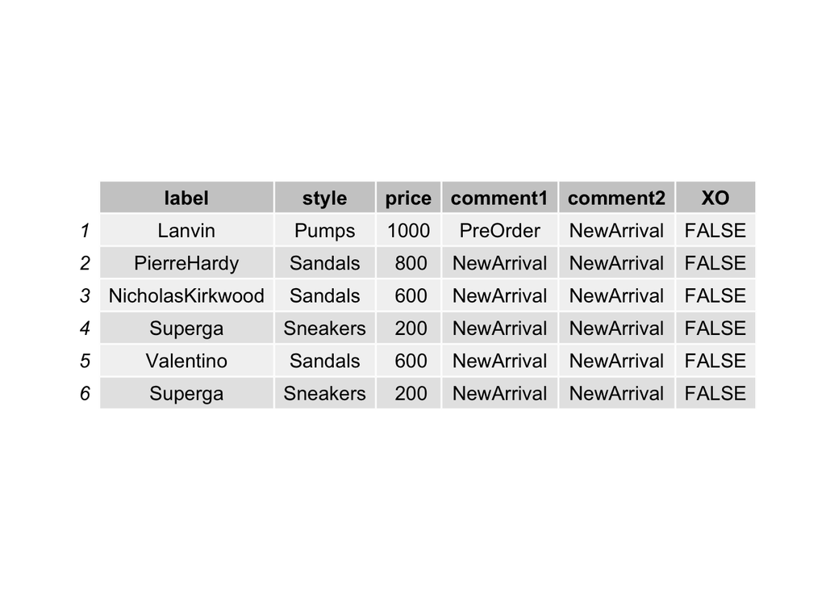

```r
library(gridExtra)
tab1 <- grid.table(head(df1))
```

```r
head(df1)
```

```
##              label    style price   comment1   comment2    XO
## 1           Lanvin    Pumps  1000   PreOrder NewArrival FALSE
## 2      PierreHardy  Sandals   800 NewArrival NewArrival FALSE
## 3 NicholasKirkwood  Sandals   600 NewArrival NewArrival FALSE
## 4          Superga Sneakers   200 NewArrival NewArrival FALSE
## 5        Valentino  Sandals   600 NewArrival NewArrival FALSE
## 6          Superga Sneakers   200 NewArrival NewArrival FALSE
```

Now, I split the data into a training sample and a testing data set and drop any unused levels in the training and testing samples.

```r
set.seed(3456)
trainIndex <- createDataPartition(df2$price, p = .8, list = FALSE)
head(trainIndex)
```

```
##      Resample1
## [1,]         1
## [2,]         2
## [3,]         3
## [4,]         4
## [5,]         5
## [6,]         6
```

```r
DFTrain <- df2[ trainIndex,]
DFTest  <- df2[-trainIndex,]

DFTest <- droplevels(DFTest)
DFTrain <- droplevels(DFTrain)
```

First, I use the decision tree to build a model.

```r
rtGrid = expand.grid(cp=seq(0.01, 0.2, by = 0.005))
ctrl <- trainControl(method = "cv", number = 10, verboseIter = T)

rtTune <- train(price ~ ., data = DFTrain,
                  method = "rpart",
                  tuneGrid = rtGrid,
                  trControl = ctrl
                )

rtTune
```

[output not shown]

Now plot the result and the best cp value. I use fancyRpartPlot to make a fancy tree plot.

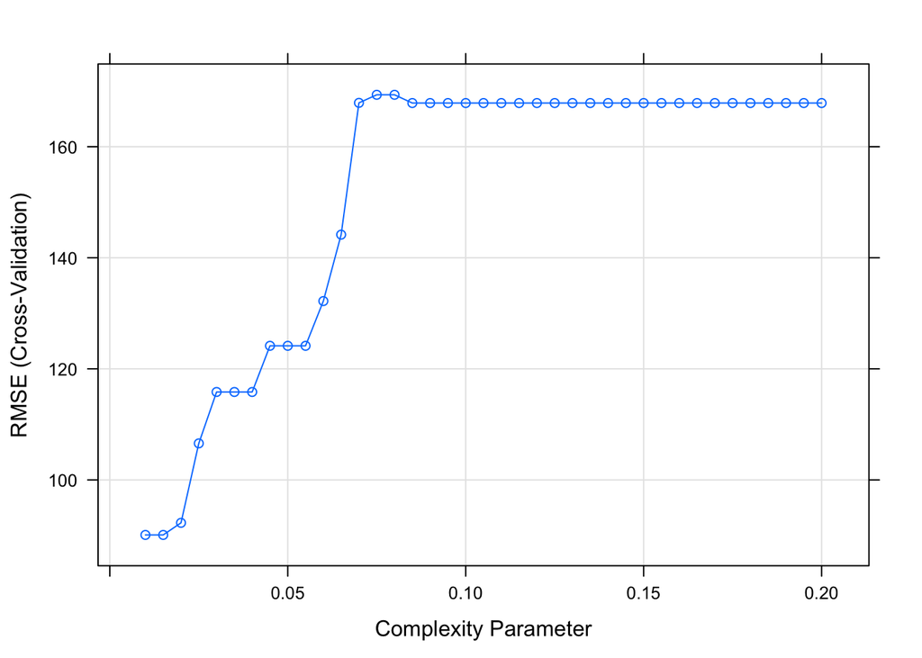

```r
plot(rtTune)
```

```r
rtTune$bestTune
```

```
##      cp
## 2 0.015
```

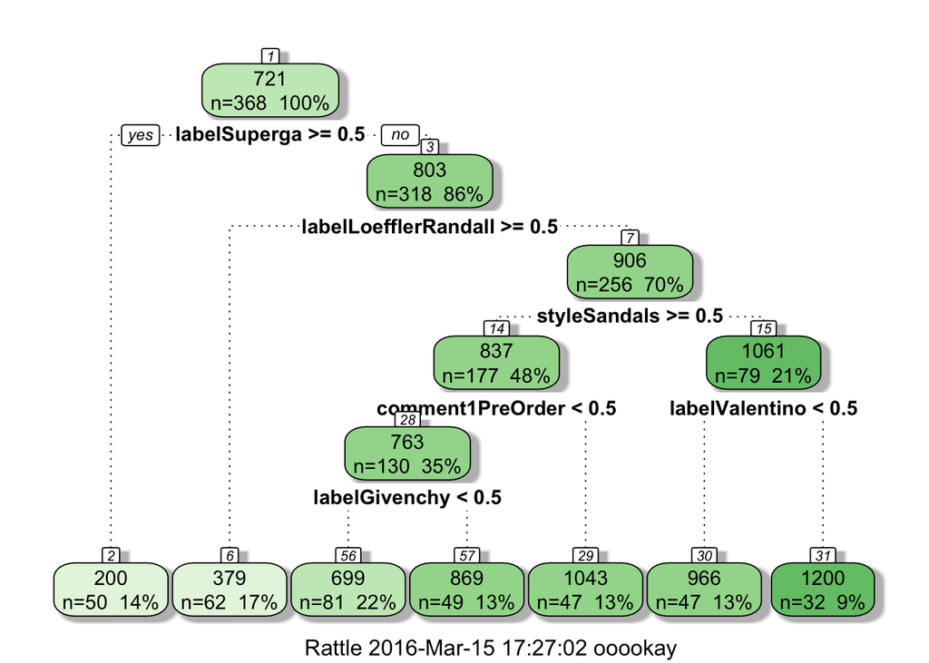

```r
fancyRpartPlot(rtTune$finalModel)
```

Then, I predict price using the test sample. The accuracy is quite low. I might get data from another website.

```r
#DFTest <- DFTest[-c(8,12,18),]
#DFTest <- DFTest[-c(1,6),]
#DFTest <- DFTest[-6,]
#DFTest <- DFTest[-10,]
pr_rt <- predict(rtTune, newdata = DFTest)
pr_rt <- round(pr_rt, -2)
rt_CM <- confusionMatrix(pr_rt, DFTest$price)
rt_CM
```

```
## Confusion Matrix and Statistics
##
##           Reference
## Prediction 200 300 400 600 700 800 900 1000 1100 1200
##       200   10   0   0   0   0   0   0    0    0    0
##       300    0   0   0   0   0   0   0    0    0    0
##       400    0   7  11   0   0   0   0    0    0    0
##       600    0   0   0   0   0   0   0    0    0    0
##       700    0   0   0   5   8   6   0    0    0    0
##       800    0   0   0   0   0   0   0    0    0    0
##       900    0   0   0   0   4   0   4    3    0    0
##       1000   0   0   0   0   0   5   4    9    6    2
##       1100   0   0   0   0   0   0   0    0    0    0
##       1200   0   0   0   0   0   0   0    0    0    8
##
## Overall Statistics
##
##                Accuracy : 0.5435
##                  95% CI : (0.4363, 0.6478)
##     No Information Rate : 0.1304
##     P-Value [Acc > NIR] : < 2.2e-16
##
##                   Kappa : 0.4819
##  Mcnemar's Test P-Value : NA
##
## Statistics by Class:
##
##                      Class: 200 Class: 300 Class: 400 Class: 600
## Sensitivity              1.0000    0.00000     1.0000    0.00000
## Specificity              1.0000    1.00000     0.9136    1.00000
## Pos Pred Value           1.0000        NaN     0.6111        NaN
## Neg Pred Value           1.0000    0.92391     1.0000    0.94565
## Prevalence               0.1087    0.07609     0.1196    0.05435
## Detection Rate           0.1087    0.00000     0.1196    0.00000
## Detection Prevalence     0.1087    0.00000     0.1957    0.00000
## Balanced Accuracy        1.0000    0.50000     0.9568    0.50000
##                      Class: 700 Class: 800 Class: 900 Class: 1000
## Sensitivity             0.66667     0.0000    0.50000     0.75000
## Specificity             0.86250     1.0000    0.91667     0.78750
## Pos Pred Value          0.42105        NaN    0.36364     0.34615
## Neg Pred Value          0.94521     0.8804    0.95062     0.95455
## Prevalence              0.13043     0.1196    0.08696     0.13043
## Detection Rate          0.08696     0.0000    0.04348     0.09783
## Detection Prevalence    0.20652     0.0000    0.11957     0.28261
## Balanced Accuracy       0.76458     0.5000    0.70833     0.76875
##                      Class: 1100 Class: 1200
## Sensitivity              0.00000     0.80000
## Specificity              1.00000     1.00000
## Pos Pred Value               NaN     1.00000
## Neg Pred Value           0.93478     0.97619
## Prevalence               0.06522     0.10870
## Detection Rate           0.00000     0.08696
## Detection Prevalence     0.00000     0.08696
## Balanced Accuracy        0.50000     0.90000
```

I also try using conditional inference tree (ctree) to predict price.

```r
ctreeCARET <- train(price ~ ., data = DFTrain, method = "ctree")
#plot(ctreeCARET$finalModel,
     #type = "simple",
#    inner_panel=node_inner(ctreeCARET$finalModel,
                 # short variable names
#       pval = FALSE,                 # no p-values
#       id = FALSE),                  # no id of node
#    terminal_panel=node_terminal(ctreeCARET$finalModel,
#       abbreviate = TRUE,
#       digits = 1,                   # few digits on numbers
 #      fill = c("white"),            # make box white not grey
 #      id = FALSE))

png("barney_ct.png", res=100, height=900, width=1200)
   plot(ctreeCARET$finalModel,
        inner_panel=node_inner(ctreeCARET$finalModel,
                 # short variable names
        pval = FALSE,                 # no p-values
        id = FALSE),                  # no id of node
      terminal_panel=node_terminal(ctreeCARET$finalModel,
        abbreviate = TRUE,
        digits = 1,                   # few digits on numbers
        fill = c("white"),            # make box white not grey
        id = FALSE))
dev.off()
```

[output not shown]

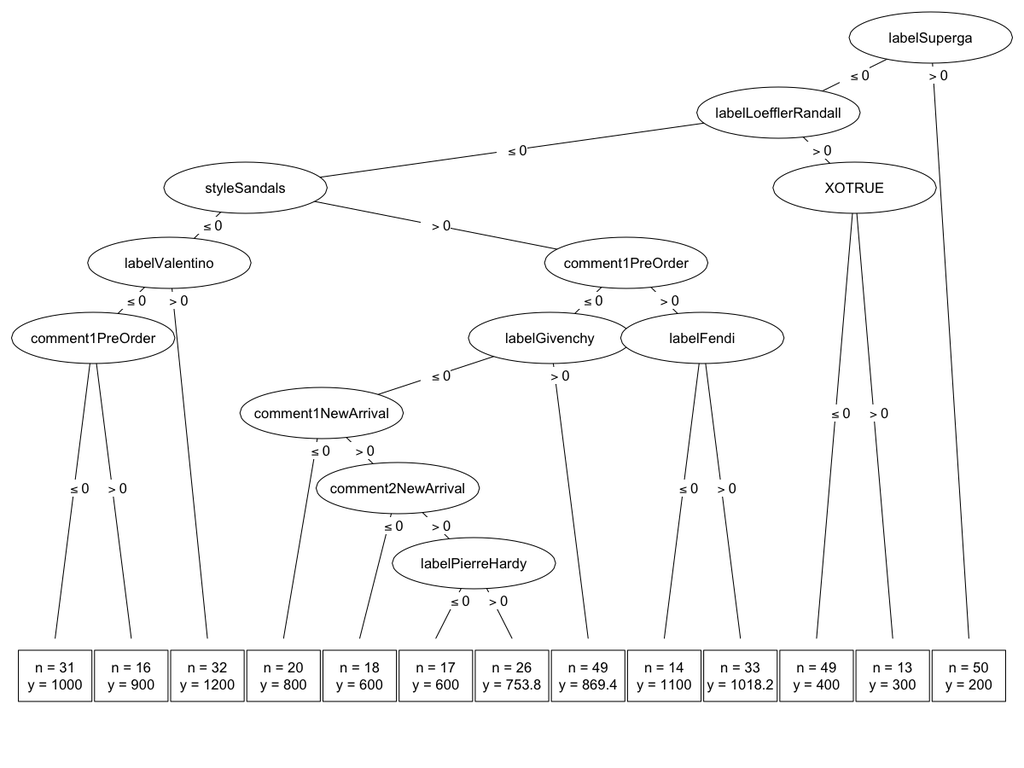

```r
#fancyRpartPlot(ctreeCARET)
pr_rt <- predict(ctreeCARET, newdata = DFTest)
pr_rt <- round(pr_rt, -2)
rt_CM <- confusionMatrix(pr_rt, DFTest$price)
rt_CM
```

[output not shown]

Below is for random forest that doesn’t work.

```r
#DFTest$popularity <- as.factor(DFTest$popularity)
DFTest$price <- as.integer(DFTest$price)
DFTest$comment1 <- as.factor(DFTest$comment1)
DFTest$comment2 <- as.factor(DFTest$comment2)
DFTest$label <- as.factor(DFTest$label)
DFTest$style <- as.factor(DFTest$style)
df1$comment1 <- as.factor(df1$comment1)
df1$comment2 <- as.factor(df1$comment2)
df1$label <- as.factor(df1$label)
df1$style <- as.factor(df1$style)
df1$price <- as.integer(df1$price)
#DFTrain$popularity <- as.factor(DFTrain$popularity)
DFTrain$price <- as.integer(DFTrain$price)
DFTrain$comment1 <- as.factor(DFTrain$comment1)
DFTrain$comment2 <- as.factor(DFTrain$comment2)
DFTrain$label <- as.factor(DFTrain$label)
DFTrain$style <- as.factor(DFTrain$style)
```

The following does not work…

```r
rfNOCARET <- randomForest(price ~ ., data=DFTrain)
                          #, ntree=2)
pr_rt <- predict(rfNOCARET, newdata = DFTest)
pr_rt <- round(pr_rt, -2)
rt_CM <- confusionMatrix(pr_rt, DFTest$price)
rt_CM
```